# Introduction

## Dataset

Using data from "The Ryerson Audio-Visual Database of Emotional Speech and Song (RAVDESS)" by Livingstone & Russo is licensed under CC BY-NA-SC 4.0.

https://zenodo.org/record/1188976

The file is **Audio_Speech_Actors_01-24**

## Data Organization

Check out our Kaggle Speech emotion dataset.

Files

File naming convention

Filename identifiers

- Modality (01 = full-AV, 02 = video-only, 03 = audio-only).
- Vocal channel (01 = speech, 02 = song).
- Emotion (01 = neutral, 02 = calm, 03 = happy, 04 = sad, 05 = angry, 06 = fearful, 07 = disgust, 08 = surprised).
- Emotional intensity (01 = normal, 02 = strong). NOTE: There is no strong intensity for the 'neutral' emotion.
- Statement (01 = "Kids are talking by the door", 02 = "Dogs are sitting by the door").
- Repetition (01 = 1st repetition, 02 = 2nd repetition).
- Actor (01 to 24. Odd numbered actors are male, even numbered actors are female).

Filename example: 03-02-06-01-02-01-12.wav

- Audio-only (03)
- Song (02)
- Fearful (06)
- Normal intensity (01)
- Statement "dogs" (02)
- 1st Repetition (01)
- 12th Actor (12)
- Female, as the actor ID number is even.

How to cite the RAVDESS

Academic citation

If you use the RAVDESS in an academic publication, please use the following citation: Livingstone SR, Russo FA (2018) The Ryerson Audio-Visual Database of Emotional Speech and Song (RAVDESS): A dynamic, multimodal set of facial and vocal expressions in North American English. PLoS ONE 13(5): e0196391. https://doi.org/10.1371/journal.pone.0196391.

All other attributions

If you use the RAVDESS in a form other than an academic publication, such as in a blog post, school project, or non-commercial product, please use the following attribution: "The Ryerson Audio-Visual Database of Emotional Speech and Song (RAVDESS)" by Livingstone & Russo is licensed under CC BY-NA-SC 4.0.

# Packages

```python
# OS Manipulation
import os
from glob import glob
import argparse
from scipy.io import wavfile
from tqdm import tqdm
import pickle
import watermark

# Basic Python
import numpy as np
import pandas as pd
import matplotlib.pyplot as plt
import math
import seaborn as sns
import statistics
from scipy import stats
import pylab

# Audio Manipulation
import librosa
import librosa.display
import kapre
import python_speech_features as psf
from python_speech_features import mfcc, logfbank
from librosa.core import resample, to_mono
from kapre.time_frequency import Melspectrogram
from kapre.utils import Normalization2D
from kapre.augmentation import AdditiveNoise
from playsound import playsound

# TensorFlow
import tensorflow as tf
from tensorflow import keras
from tensorflow.keras import layers
from tensorflow.keras import Sequential
from tensorflow.keras.layers import Conv1D, Conv2D, MaxPooling2D, MaxPooling1D, Flatten, LSTM, Bidirectional
from tensorflow.keras.layers import Dropout, Dense, TimeDistributed, Input, Permute, Reshape
from tensorflow.keras.models import Model
from tensorflow.keras.models import load_model
from tensorflow.keras.regularizers import l2
from tensorflow.keras.callbacks import CSVLogger, ModelCheckpoint
from tensorflow.keras.utils import to_categorical

# Sklearn
from sklearn.utils.class_weight import compute_class_weight
from sklearn.preprocessing import LabelEncoder, OneHotEncoder
from sklearn.model_selection import train_test_split
from sklearn.metrics import accuracy_score, precision_score, recall_score, f1_score
from sklearn.metrics import roc_auc_score, roc_curve, auc, confusion_matrix, plot_confusion_matrix, precision_recall_curve
```

```python
# Package versions
%load_ext watermark
%watermark -v -iv
```

```
librosa          0.7.2
tensorflow.keras 2.3.0-tf
watermark        2.0.2
pandas           1.0.5
numpy            1.18.5
argparse         1.1
seaborn          0.10.1
kapre            0.1.7
tensorflow       2.2.0
CPython 3.7.7
IPython 7.16.1
```

```python
'''
# cuDNN was having problems with the Kapre custom layers (Melspectogram)
# This made the bug go away... that's all I know
physical_devices = tf.config.experimental.list_physical_devices('GPU')
tf.config.experimental.set_memory_growth(physical_devices[0], True)
'''
```

```
"\n# cuDNN was having problems with the Kapre custom layers (Melspectogram)\n# This made the bug go away... that's all I know\nphysical_devices = tf.config.experimental.list_physical_devices('GPU')\ntf.config.experimental.set_memory_growth(physical_devices[0], True)\n"
```

# Loading Dataset

```python
# Check source directory
len(os.listdir('Audio_Speech_Actors_01-24/'))
```

```
24
```

```python
%%time

# Looping through 24 folders, each with 60 samples, for a total of 1440 audio files.
# The folders are named 'Actor_01' through 'Actor_24'

# Definig the root directory name
root_dir = 'Audio_Speech_Actors_01-24'

# Dictionaries to receive the outputs
files = {}
sampling_rate = {}

# Loop through all directories
for itens in range(1, len(os.listdir(root_dir))+1):

    # Define the folder path for that specific actor
    if len(str(itens)) == 1:
        audio_dir = root_dir + '/Actor_' + str('0') + str(itens)
    else:
        audio_dir = root_dir + '/Actor_' + str(itens)

    # Extract the path to all the directory's files
    audio_files = glob(audio_dir + '/*.wav')

    # Store the path and sampling rate for each '.wav' file in the folder
    for i in range(len(audio_files)):
        x = audio_files[i]
        audio, sfreq = librosa.load(audio_files[i], sr = None)
        files[x] = len(audio) / sfreq
        sampling_rate[x] = sfreq
```

```
Wall time: 47.5 s
```

```python
# Check if all sampling rates are equal
all(value==48000 for value in sampling_rate.values())
```

```
True
```

```python
# Put everying into a dataframe
audio_df = pd.DataFrame()

for keys, values in files.items():
    audio_df.at[keys,'file_length'] = values

audio_df
```

|  | file_length |
| --- | --- |
| Audio_Speech_Actors_01-24/Actor_01\03-01-01-01-01-01-01.wav | 3.303292 |
| Audio_Speech_Actors_01-24/Actor_01\03-01-01-01-01-02-01.wav | 3.336667 |
| Audio_Speech_Actors_01-24/Actor_01\03-01-01-01-02-01-01.wav | 3.269917 |
| Audio_Speech_Actors_01-24/Actor_01\03-01-01-01-02-02-01.wav | 3.169833 |
| Audio_Speech_Actors_01-24/Actor_01\03-01-02-01-01-01-01.wav | 3.536854 |
| ... | ... |
| Audio_Speech_Actors_01-24/Actor_24\03-01-08-01-02-02-24.wav | 3.403396 |
| Audio_Speech_Actors_01-24/Actor_24\03-01-08-02-01-01-24.wav | 3.937271 |
| Audio_Speech_Actors_01-24/Actor_24\03-01-08-02-01-02-24.wav | 3.970625 |
| Audio_Speech_Actors_01-24/Actor_24\03-01-08-02-02-01-24.wav | 3.670333 |
| Audio_Speech_Actors_01-24/Actor_24\03-01-08-02-02-02-24.wav | 3.636958 |

1440 rows × 1 columns

```python
# Dictionary with emotions
emotion_dict = {'01': 'neutral',
                '02': 'calm',
                '03': 'happy',
                '04': 'sad',
                '05': 'angry',
                '06': 'fearful',
                '07': 'disgust',
                '08': 'surprised'}
```

```python
# Lenght of the string indicating the audiofile path
len(audio_df.index[0])
```

```
59
```

```python
# Encoding example
audio_df.index[0][35:]
```

```
'03-01-01-01-01-01-01.wav'
```

String positions x encoding:

- 35-36 → modality
- 38-39 → voice channel
- 41-42 → emotion
- 44-45 → intensity
- 47-48 → statement
- 50-51 → repetition
- 53-54 → actor (where odd numbers mean male and even numbers mean female)
- 56-59 → .wav

```python
# Create column with emotion IDs
for i, row in audio_df.iterrows():
    audio_df.at[i, 'emotion_id'] = i[41:43]
```

```python
# Create column with emotion labels
audio_df['emotion'] = audio_df['emotion_id'].map(emotion_dict)
```

```python
audio_df
```

|  | file_length | emotion_id | emotion |
| --- | --- | --- | --- |
| Audio_Speech_Actors_01-24/Actor_01\03-01-01-01-01-01-01.wav | 3.303292 | 01 | neutral |
| Audio_Speech_Actors_01-24/Actor_01\03-01-01-01-01-02-01.wav | 3.336667 | 01 | neutral |
| Audio_Speech_Actors_01-24/Actor_01\03-01-01-01-02-01-01.wav | 3.269917 | 01 | neutral |
| Audio_Speech_Actors_01-24/Actor_01\03-01-01-01-02-02-01.wav | 3.169833 | 01 | neutral |
| Audio_Speech_Actors_01-24/Actor_01\03-01-02-01-01-01-01.wav | 3.536854 | 02 | calm |
| ... | ... | ... | ... |
| Audio_Speech_Actors_01-24/Actor_24\03-01-08-01-02-02-24.wav | 3.403396 | 08 | surprised |
| Audio_Speech_Actors_01-24/Actor_24\03-01-08-02-01-01-24.wav | 3.937271 | 08 | surprised |
| Audio_Speech_Actors_01-24/Actor_24\03-01-08-02-01-02-24.wav | 3.970625 | 08 | surprised |
| Audio_Speech_Actors_01-24/Actor_24\03-01-08-02-02-01-24.wav | 3.670333 | 08 | surprised |
| Audio_Speech_Actors_01-24/Actor_24\03-01-08-02-02-02-24.wav | 3.636958 | 08 | surprised |

1440 rows × 3 columns

# Exploratory Analysis

```python
# Longest audio file
a = audio_df['file_length'].argmax()
b = audio_df.iloc[a].name
print(f'{audio_df.iloc[a]}')
playsound(b)
```

```
file_length    5.27194
emotion_id          07
emotion        disgust
Name: Audio_Speech_Actors_01-24/Actor_19\03-01-07-02-01-02-19.wav, dtype: object
```

```python
# Shortest audio file
a = audio_df['file_length'].argmin()
b = audio_df.iloc[a].name
print(f'{audio_df.iloc[a]}')
playsound(b)
```

```
file_length    2.93627
emotion_id          02
emotion           calm
Name: Audio_Speech_Actors_01-24/Actor_13\03-01-02-01-02-02-13.wav, dtype: object
```

```python
# Play a random audio
b = np.random.choice(audio_df.index)
a = audio_df[audio_df.index == b]
print(a.index)
print(a.columns)
print(a.values)
playsound(b)
```

```
Index(['Audio_Speech_Actors_01-24/Actor_07\03-01-02-01-01-01-07.wav'], dtype='object')
Index(['file_length', 'emotion_id', 'emotion'], dtype='object')
[[3.470125 '02' 'calm']]
```

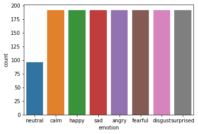

```python
# Dataset balance by emotion
sns.countplot(x = 'emotion', data = audio_df)
```

```python
# Emotion balance by audio length
# Reindexing to keep the original label order
emotion_length = audio_df.groupby('emotion').sum().reindex(emotion_dict.values())
emotion_length
```

| emotion | file_length |
| --- | --- |
| neutral | 336.302667 |
| calm | 728.794792 |
| happy | 698.531042 |
| sad | 709.342000 |
| angry | 743.309521 |
| fearful | 686.252333 |
| disgust | 756.822667 |
| surprised | 669.602312 |

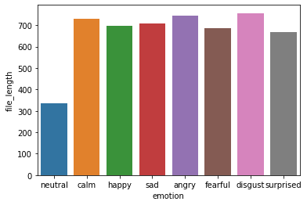

```python
# Emotion balance by audio length
sns.barplot(x = emotion_length.index, y = emotion_length.file_length)
```

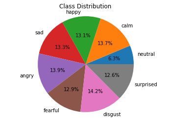

```python
# Plot class distribution
fig, ax = plt.subplots()
ax.set_title('Class Distribution')
ax.pie(emotion_length.file_length, labels = emotion_length.index,
      autopct='%1.1f%%')
ax.axis('equal')
plt.show()
```

```python
np.random.choice(audio_df.index)
```

```
'Audio_Speech_Actors_01-24/Actor_09\\03-01-05-02-01-01-09.wav'
```

Reference video on digital audio processing I: https://www.youtube.com/watch?v=Z7YM-HAz-IY

Reference video on digital audio processing II: https://www.youtube.com/watch?v=RMfeYitdO-c&feature=youtu.be

Speech Processing for Machine Learning: https://haythamfayek.com/2016/04/21/speech-processing-for-machine-learning.html

Reference on getting from audio to melspetrogram: https://towardsdatascience.com/getting-to-know-the-mel-spectrogram-31bca3e2d9d0

The Mel Spectrogram is the result of the following pipeline:

**1) Separate to windows:** Sample the input with windows of size `n_fft=2048`, making hops of size `hop_length=512` each time to sample the next window.

**2) Compute FFT** (Fast Fourier Transform) for each window to transform from time domain to frequency domain.

**3) Generate a Mel scale:** Take the entire frequency spectrum, and separate it into `n_mels=128` evenly spaced frequencies. And what do we mean by evenly spaced? not by distance on the frequency dimension, but distance as it is heard by the human ear.

**4) Generate Spectrogram:** For each window, decompose the magnitude of the signal into its components, corresponding to the frequencies in the mel scale.

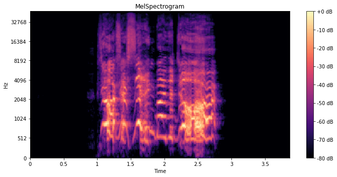

```python
# Plot the Melspectrogram of a random audio file
ORIGINAL_SR = 48000
N_MELS = 128

# Read a random file
signal, rate = librosa.load(np.random.choice(audio_df.index), sr = ORIGINAL_SR)

# Calculate the melspectrogram
melSpec = librosa.feature.melspectrogram(y=signal, sr=rate, n_mels=N_MELS)

# Convert to log scale (decibels)
melSpec_dB = librosa.power_to_db(melSpec, ref=np.max)

# Plot
plt.figure(figsize=(10, 5))
librosa.display.specshow(melSpec_dB, x_axis='time', y_axis='mel', sr=rate, fmax=ORIGINAL_SR)
plt.colorbar(format='%+1.0f dB')
plt.title("MelSpectrogram")
plt.tight_layout()
plt.show()
```

The MelSpectrogram seems to be cutting at the start and end of the audiofile.

Plotting a 3x3 with 9 MelSpectrograms to check if this is really the case

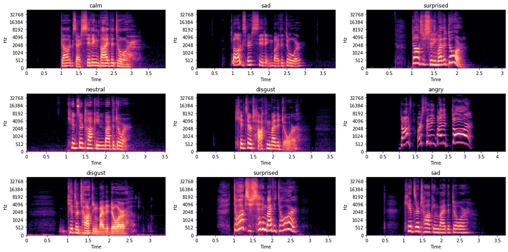

```python
# Plotting multiple Melspectrograms

# Number of plots
nrows, ncols = 3, 3
# Create figure with suplots
fig, ax = plt.subplots(nrows, ncols, figsize=(16,8))
# Define index of subplot
i = 1
# Loop through each row x column pair
for x in range(nrows):
    for y in range(ncols):
        # Define the row x column location (aka the subplot)
        plt.subplot(nrows, ncols, i)
        # Pick a random file
        random_file = np.random.choice(audio_df.index)
        # Read the random file
        signal, rate = librosa.load(random_file, sr = ORIGINAL_SR)
        # Calculate the melspectrogram
        melSpec = librosa.feature.melspectrogram(y=signal, sr=rate, n_mels=N_MELS)
        # Convert to log scale (decibels)
        melSpec_dB = librosa.power_to_db(melSpec, ref=np.max)
        # Plot melspectrogram
        librosa.display.specshow(melSpec_dB, x_axis='time', y_axis='mel', sr=rate, fmax=ORIGINAL_SR)
        # Plot emotion label
        plt.gca().set_title(audio_df[audio_df.index == random_file].emotion.values[0])
        i += 1

plt.tight_layout()
plt.show()
```

It is indeed the case that before the first second there's a lot of empty signal.

I'll employ a signal envelope to attempt to remove some of the useless parts of the audio

```python
# First plotting the signal as is
# Dictionary to store the original signal samples
signals_o = {}
```

```python
# Extracting sample data

# For each class (emotion) sample one audio file to plot
for e in list(emotion_dict.values()):
    # Pick a random index (file path) from the given emotion
    wav_name = np.random.choice(audio_df[audio_df.emotion == e].index)
    # Signal and rate
    signal, rate = librosa.load(wav_name, sr = ORIGINAL_SR)
    # Append to the original signals dictionary
    signals_o[e] = signal
```

```python
# Functio to plot signals
def plot_signals(signals):
    # Define number of rows and columns
    nrows = 2
    ncols = 4
    # Create figure and axes with subplots
    fig, axes = plt.subplots(nrows=nrows, ncols=ncols, sharex=False, sharey=True, figsize=(20,5))
    # Set plot name
    fig.suptitle('Signal Sample per Emotion', size=16)
    # Set index for the first dictionary key
    i = 0
    # Loop through each row x column pair
    for x in range(nrows):
        for y in range(ncols):
            axes[x,y].set_title(list(signals.keys())[i])
            axes[x,y].plot(list(signals.values())[i])
            axes[x,y].get_xaxis().set_visible(False)
            axes[x,y].get_yaxis().set_visible(False)
            i += 1
```

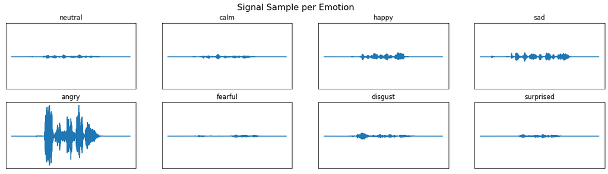

```python
# Plotting the original signals
plot_signals(signals_o)
```

```python
# Creating function to calculate the signal envelope
# Then remove dead spaace from the audio with it
# From empirical testing I found a threshold of about 0.001 to be the ideal. Half that (0.0005) works too.
def envelope(signal, rate, threshold=0.001):
    mask = []
    # pd.Series allows for easy rolling window
    # Need to take abs values otherwise all negative parts of the audio wave would be removed
    y = pd.Series(signal).apply(np.abs)
    # Window size will be a 10th of a second
    y_mean = y.rolling(window = int(rate/10), min_periods = 1, center = True).mean()
    for mean in y_mean:
        if mean > threshold:
            mask.append(True) # Appending true means keep the signal
        else:
            mask.append(False)
    return mask
```

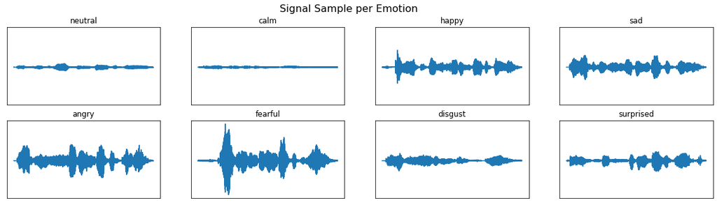

```python
# Plotting the filtered signals
signals_f = {}

# For each class (emotion) sample one audio file to plot
for e in list(emotion_dict.values()):
    # Pick a random index (file path) from the given emotion
    wav_name = np.random.choice(audio_df[audio_df.emotion == e].index)
    # Signal and rate
    signal, rate = librosa.load(wav_name, sr = ORIGINAL_SR)
    # Crease a mask to envelope the signal
    mask = envelope(signal, rate, threshold=0.001)
    # Apply the envelope
    signal = signal[mask]
    # Append to the original signals dictionary
    signals_f[e] = signal

plot_signals(signals_f)
```

```python
# List duration of the filtered samples
for i in range(len(signals_f)):
    print(f'Length of the {i+1} sample is {list(signals_f.values())[i].size/ORIGINAL_SR:.2f} seconds')
```

```
Length of the 1 sample is 1.36 seconds
Length of the 2 sample is 1.86 seconds
Length of the 3 sample is 1.93 seconds
Length of the 4 sample is 1.49 seconds
Length of the 5 sample is 1.48 seconds
Length of the 6 sample is 1.85 seconds
Length of the 7 sample is 1.35 seconds
Length of the 8 sample is 1.73 seconds
```

# Preprocessing: Signal Envelope

```python
# Leaving this utility function here as a reminder that I could downsample my audio data
# Because 48kHz is quite high of a sampling rate, and most likely 16kHz would work fine
# But initially I will not be downsampling because my dataset isn't too big to start with
# And so I don't want to lose any more data (will already lose some with the signal envelope)
def downsample_mono(path, sr):

    # Read the file on the original rate, as it results in better mono conversion than using a downsampled audio rate
    rate, wav = wavfile.read(path)

    # Convert to float32 as its required by Librosa to downsample to mono
    wav = wav.astype(np.float32, order='F')

    # Check if audio is stereo (for mono shape[1] will be empty and the try will fail)
    try:
        wav.shape[1]
        # If the audio was stereo, then convert it to mono with Librosa's to_mono
        # The input needs to be transposed because wafile returns stereo as (n,2) but Librosa expects (2,n)
        wav = to_mono(wav.T)
    except:
        pass

    # Use Librosa's resample to downsample to the desired rate
    wav = resample(wav, rate, sr)

    # Convert audio back to int16 because audio in float sounds awful (due to issues with the floating point)
    wav = wav.astype(np.int16)

    return sr, wav
```

```python
wav_name[35:55]
```

```
'03-01-08-01-02-01-15'
```

```python
def save_sample(sample, rate, wav_name):
    fn = wav_name[35:55]
    dst_path = os.path.join(TARGET_ROOT, fn + '.wav')
    if os.path.exists(dst_path):
        return
    wavfile.write(dst_path, rate, sample)
```

```python
SOURCE_ROOT = 'Audio_Speech_Actors_01-24'
TARGET_ROOT = 'dataset_cleaned'
```

```python
# Ensure target root exists
if os.path.exists(TARGET_ROOT) is False:
    os.mkdir(TARGET_ROOT)
```

```python
# List all emotions
classes = list(emotion_dict.values())
classes
```

```
['neutral', 'calm', 'happy', 'sad', 'angry', 'fearful', 'disgust', 'surprised']
```

```python
# Recursive path on the source folder to extract all wav file paths
all_paths = glob(f'{SOURCE_ROOT}/**', recursive=True)
len(all_paths)
```

```
1465
```

```python
# Keep only .wav file paths (discarding folder paths)
wav_paths = [x for x in all_paths if '.wav' in x]
len(wav_paths)
```

```
1440
```

```python
# Dictionary for the filtered signals
signals = {}
```

```python
# Applying the envelope to all audio files
# Loop through all wav_paths
for wav_name in tqdm(wav_paths):

    # Signal and rate
    signal, rate = librosa.load(wav_name, sr = ORIGINAL_SR)

    # Crease a mask to envelope the signal
    mask = envelope(signal, rate, threshold=0.001)

    # Apply the envelope
    signal = signal[mask]

    # Append the signal to the dictionary with all filtered singals
    signals[wav_name] = signal

    # Save sample
    save_sample(signal, rate, wav_name)
```

```python
# Check a random sample
b = np.random.choice(os.listdir(TARGET_ROOT))
c = os.path.join(TARGET_ROOT, b)

# Signal and rate
signal, rate = librosa.load(c, sr = ORIGINAL_SR)
print(f'File: {b}')
print(f'Signal length: {signal.shape[0]}')
print(f'Rate: {rate}')

playsound(c)
```

```
File: 03-01-02-01-02-01-16.wav
Signal length: 87842
Rate: 48000
```

```python
# Variable to gather the total length of all audio files
filtered_audio_len = []

# Loop through the dictionary of filtered signals and add the size of the signal for each audio sample
for key, value in signals.items():
    filtered_audio_len.append(value.size)
```

```python
# Adding the filtered audio lengths to my dataframe
cnt = 0
for i, row in enumerate(audio_df.iterrows()):
    audio_df.at[audio_df.index[i], 'filtered_length'] = np.array(filtered_audio_len[cnt])/ORIGINAL_SR
    cnt += 1
```

```python
audio_df
```

|  | file_length | emotion_id | emotion | filtered_length |
| --- | --- | --- | --- | --- |
| Audio_Speech_Actors_01-24/Actor_01\03-01-01-01-01-01-01.wav | 3.303292 | 01 | neutral | 1.227854 |
| Audio_Speech_Actors_01-24/Actor_01\03-01-01-01-01-02-01.wav | 3.336667 | 01 | neutral | 1.257708 |
| Audio_Speech_Actors_01-24/Actor_01\03-01-01-01-02-01-01.wav | 3.269917 | 01 | neutral | 1.250813 |
| Audio_Speech_Actors_01-24/Actor_01\03-01-01-01-02-02-01.wav | 3.169833 | 01 | neutral | 1.205583 |
| Audio_Speech_Actors_01-24/Actor_01\03-01-02-01-01-01-01.wav | 3.536854 | 02 | calm | 1.263771 |
| ... | ... | ... | ... | ... |
| Audio_Speech_Actors_01-24/Actor_24\03-01-08-01-02-02-24.wav | 3.403396 | 08 | surprised | 1.431229 |
| Audio_Speech_Actors_01-24/Actor_24\03-01-08-02-01-01-24.wav | 3.937271 | 08 | surprised | 1.975021 |
| Audio_Speech_Actors_01-24/Actor_24\03-01-08-02-01-02-24.wav | 3.970625 | 08 | surprised | 1.960167 |
| Audio_Speech_Actors_01-24/Actor_24\03-01-08-02-02-01-24.wav | 3.670333 | 08 | surprised | 1.939896 |
| Audio_Speech_Actors_01-24/Actor_24\03-01-08-02-02-02-24.wav | 3.636958 | 08 | surprised | 1.846563 |

1440 rows × 4 columns

```python
print('STATISTICS FOR THE FILTERED AUDIO FILES')
print(f'Median sample size:     {statistics.median(audio_df.filtered_length):.2f} seconds')
print(f'Mean sample size:       {statistics.mean(audio_df.filtered_length):.2f} seconds')
print(f'Stdev of sample size:   {statistics.stdev(audio_df.filtered_length):.2f} seconds')
print(f'Maximum of sample size: {max(filtered_audio_len)/ORIGINAL_SR:.2f} seconds')
print(f'Minimum of sample size: {min(filtered_audio_len)/ORIGINAL_SR:.2f} seconds')
```

```
STATISTICS FOR THE FILTERED AUDIO FILES
Median sample size:     1.68 seconds
Mean sample size:       1.72 seconds
Stdev of sample size:   0.42 seconds
Maximum of sample size: 3.73 seconds
Minimum of sample size: 0.25 seconds
```

```python
print('STATISTICS FOR THE ORIGINAL AUDIO FILES')
print(f'Median sample size:     {statistics.median(audio_df.file_length):.2f} seconds')
print(f'Mean sample size:       {statistics.mean(audio_df.file_length):.2f} seconds')
print(f'Stdev of sample size:   {statistics.stdev(audio_df.file_length):.2f} seconds')
print(f'Maximum of sample size: {max(audio_df.file_length):.2f} seconds')
print(f'Minimum of sample size: {min(audio_df.file_length):.2f} seconds')
```

```
STATISTICS FOR THE ORIGINAL AUDIO FILES
Median sample size:     3.67 seconds
Mean sample size:       3.70 seconds
Stdev of sample size:   0.34 seconds
Maximum of sample size: 5.27 seconds
Minimum of sample size: 2.94 seconds
```

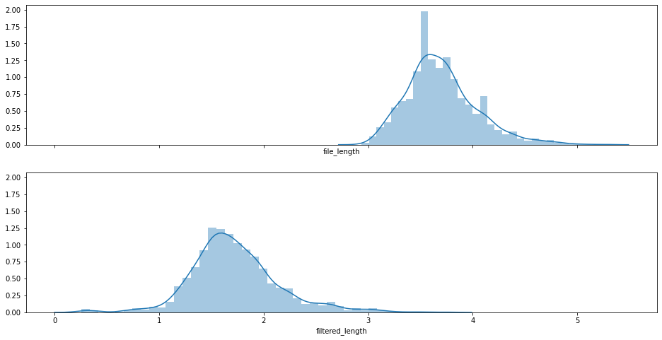

```python
# Histogram comparing the original and filtered audio datasets
fig, ax = plt.subplots(2, 1, figsize=(16,8), sharey=True, sharex=True)

# Histogram of original audio length
sns.distplot(audio_df.file_length, ax=ax[0], label='Original Audio')

# Histogram of filtered_audio_len
sns.distplot(audio_df.filtered_length, ax=ax[1], label='Filtered Audio')
```

I need to make all samples on the filtered dataset the same size, so they can be fed to a neural network.

```python
# Checking different percentiles to assess the best length to choose
print(f' 1st percentile: {np.percentile(audio_df.filtered_length, 1):.2f} seconds')
print(f' 5th percentile: {np.percentile(audio_df.filtered_length, 5):.2f} seconds')
print(f'10th percentile: {np.percentile(audio_df.filtered_length, 10):.2f} seconds')
print(f'50th percentile: {np.percentile(audio_df.filtered_length, 50):.2f} seconds')
print(f'90th percentile: {np.percentile(audio_df.filtered_length, 90):.2f} seconds')
print(f'95th percentile: {np.percentile(audio_df.filtered_length, 95):.2f} seconds')
print(f'99th percentile: {np.percentile(audio_df.filtered_length, 99):.2f} seconds')
```

```
 1st percentile: 0.74 seconds
 5th percentile: 1.16 seconds
10th percentile: 1.28 seconds
50th percentile: 1.68 seconds
90th percentile: 2.24 seconds
95th percentile: 2.50 seconds
99th percentile: 3.02 seconds
```

```python
# Check percentiles of specific audio lengths
print(f' Percentile of files above 1.0 seconds: {stats.percentileofscore(audio_df.filtered_length, 1.0)}')
print(f' Percentile of files above 1.5 seconds: {stats.percentileofscore(audio_df.filtered_length, 1.5)}')
print(f' Percentile of files above 2.0 seconds: {stats.percentileofscore(audio_df.filtered_length, 2.0)}')
print(f' Percentile of files above 2.5 seconds: {stats.percentileofscore(audio_df.filtered_length, 2.5)}')
print(f' Percentile of files above 3.0 seconds: {stats.percentileofscore(audio_df.filtered_length, 3.0)}')
```

```
 Percentile of files above 1.0 seconds: 2.638888888888889
 Percentile of files above 1.5 seconds: 28.541666666666668
 Percentile of files above 2.0 seconds: 80.34722222222223
 Percentile of files above 2.5 seconds: 94.86111111111111
 Percentile of files above 3.0 seconds: 98.88888888888889
```

There is a good case to be made for the chosen audio lengths to be the mean or median, as it would imply the least manipulation (padding or cutting) on the audio data.

Yet as long as all classes (emotions) get more or less the same amount of padding with zeros, then I think it makes more sense for a longer audio length to be chosen, as it reduces the loss of data.

```python
# Emotion balance by audio length
# Reindexing to keep the original label order
emotion_length = audio_df.groupby('emotion').sum().reindex(emotion_dict.values())
emotion_length
```

| emotion | file_length | filtered_length |
| --- | --- | --- |
| neutral | 336.302667 | 140.619000 |
| calm | 728.794792 | 304.302708 |
| happy | 698.531042 | 334.778208 |
| sad | 709.342000 | 314.779625 |
| angry | 743.309521 | 383.101521 |
| fearful | 686.252333 | 341.911167 |
| disgust | 756.822667 | 362.889917 |
| surprised | 669.602312 | 297.691917 |

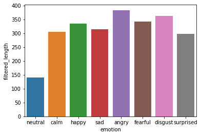

```python
# Emotion balance by audio length
sns.barplot(x = emotion_length.index, y = emotion_length.filtered_length)
```

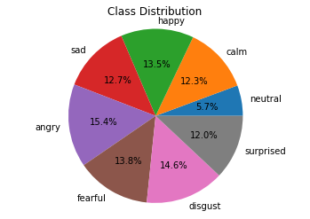

```python
# Plot class distribution
fig, ax = plt.subplots()
ax.set_title('Class Distribution')
ax.pie(emotion_length.filtered_length, labels = emotion_length.index,
      autopct='%1.1f%%')
ax.axis('equal')
plt.show()
```

There is a good class balance in the cleaned dataset, with the notable exception of the undersampled neutral class.

All classes seem to have lost around 50% of audio length, although that's not necessarily a 50% loss of data as most of the audio removed with the envelope was empty space.

I will opt to move ahead with a 2 second audio length, which means that around 80% of the samples will need some zero-padding and 20% will need some cutting.

# Preprocessing: Standardizing Length

```python
# Hyperparameters
DT = 2.0 # Delta time
AUDIO_LEN = ORIGINAL_SR * DT
```

```python
# Create a new dataframe indexed at the cleaned audio files
df = audio_df.copy()
```

```python
# Create new index mapping to the dataset_cleaned path
new_index = [TARGET_ROOT + i[34:] for i in audio_df.index]
```

```python
# Map the index to the filenames on the dataset_cleaned folder
df.index = new_index
```

```python
df
```

|  | file_length | emotion_id | emotion | filtered_length |
| --- | --- | --- | --- | --- |
| dataset_cleaned\03-01-01-01-01-01-01.wav | 3.303292 | 01 | neutral | 1.227854 |
| dataset_cleaned\03-01-01-01-01-02-01.wav | 3.336667 | 01 | neutral | 1.257708 |
| dataset_cleaned\03-01-01-01-02-01-01.wav | 3.269917 | 01 | neutral | 1.250813 |
| dataset_cleaned\03-01-01-01-02-02-01.wav | 3.169833 | 01 | neutral | 1.205583 |
| dataset_cleaned\03-01-02-01-01-01-01.wav | 3.536854 | 02 | calm | 1.263771 |
| ... | ... | ... | ... | ... |
| dataset_cleaned\03-01-08-01-02-02-24.wav | 3.403396 | 08 | surprised | 1.431229 |
| dataset_cleaned\03-01-08-02-01-01-24.wav | 3.937271 | 08 | surprised | 1.975021 |
| dataset_cleaned\03-01-08-02-01-02-24.wav | 3.970625 | 08 | surprised | 1.960167 |
| dataset_cleaned\03-01-08-02-02-01-24.wav | 3.670333 | 08 | surprised | 1.939896 |
| dataset_cleaned\03-01-08-02-02-02-24.wav | 3.636958 | 08 | surprised | 1.846563 |

1440 rows × 4 columns

```python
# Longest audio file
a = df['filtered_length'].argmax()
b = df.iloc[a].name
print(f'{df.iloc[a]}')
playsound(b)
```

```
file_length        4.17083
emotion_id              06
emotion            fearful
filtered_length    3.73425
Name: dataset_cleaned\03-01-06-02-01-02-20.wav, dtype: object
```

```python
# Shorted audio file
a = df['filtered_length'].argmin()
b = df.iloc[a].name
print(f'{df.iloc[a]}')
playsound(b)
```

```
file_length         3.63698
emotion_id               02
emotion                calm
filtered_length    0.253417
Name: dataset_cleaned\03-01-02-02-02-02-20.wav, dtype: object
```

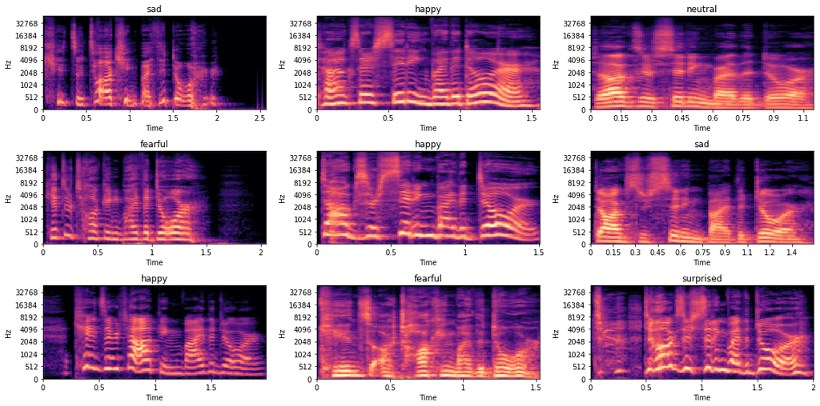

```python
# Plotting multiple Melspectrograms - now showing the audio after applying the signal envelope

# Number of plots
nrows, ncols = 3, 3
# Create figure with suplots
fig, ax = plt.subplots(nrows, ncols, figsize=(16,8))
# Define index of subplot
i = 1
# Loop through each row x column pair
for x in range(nrows):
    for y in range(ncols):
        # Define the row x column location (aka the subplot)
        plt.subplot(nrows, ncols, i)
        # Pick a random file
        random_file = np.random.choice(df.index)
        # Read the random file
        signal, rate = librosa.load(random_file, sr = ORIGINAL_SR)
        # Calculate the melspectrogram
        melSpec = librosa.feature.melspectrogram(y=signal, sr=rate, n_mels=N_MELS)
        # Convert to log scale (decibels)
        melSpec_dB = librosa.power_to_db(melSpec, ref=np.max)
        # Plot melspectrogram
        librosa.display.specshow(melSpec_dB, x_axis='time', y_axis='mel', sr=rate, fmax=ORIGINAL_SR)
        # Plot emotion label
        plt.gca().set_title(df[df.index == random_file].emotion.values[0])
        i += 1

plt.tight_layout()
plt.show()
```

The timewindows are of varying lenght, exactly what I'm about to fix!

```python
# Recursive path on the source folder (dataset_cleaned) to extract all wav file paths
all_paths = glob(f'{TARGET_ROOT}/**', recursive=True)
len(all_paths)

# Keep only .wav file paths (discarding folder paths)
wav_paths = [x for x in all_paths if '.wav' in x]
len(wav_paths)
```

```
1440
```

```python
FINAL_ROOT = 'dataset_final'
```

```python
# Ensure target root exists
if os.path.exists(FINAL_ROOT) is False:
    os.mkdir(FINAL_ROOT)
```

```python
wav_paths[0][16:36]
```

```
'03-01-01-01-01-01-01'
```

```python
def save_sample_final(sample, rate, wav_name):
    fn = wav_name[16:36]
    dst_path = os.path.join(FINAL_ROOT, fn + '.wav')
    if os.path.exists(dst_path):
        return
    wavfile.write(dst_path, rate, sample)
```

```python
# Dictionary with final signals
signals_final = {}
```

```python
# Loop through all audio files
for wav_name in tqdm(wav_paths):

    # Signal and rate
    signal, rate = librosa.load(wav_name, sr = ORIGINAL_SR)

    # Resample to 16000 with librosa
    #signal = resample(signal, orig_sr=rate, target_sr=16000)
    #rate = 16000
    #AUDIO_LEN = 32000
    # Downsampling did not improve performance

    # Check if audio is shorter (or equal) than AUDIO_LEN (2 seconds)
    if signal.shape[0] <= AUDIO_LEN:

        # Create an array the size of AUDIO_LEN filled with zeros
        sample = np.zeros(shape=(int(AUDIO_LEN)), dtype=np.float32)

        # Overwrite the zeroes array with data from the wav_name
        sample[:signal.shape[0]] = signal

        # Dictionary with final signals
        signals_final[wav_name] = sample

        # Save
        save_sample_final(sample, rate, wav_name)

    # Else check is the audio is longer than AUDIO_LEN (2 seconds), which is has to be
    elif signal.shape[0] > AUDIO_LEN:

        # Calculate how much longer it is
        extra_len = signal.shape[0] - AUDIO_LEN

        # Split the difference in half (and take only the integer part)
        half_dif = extra_len//2

        # Define start and stop indexes to cut the audio
        start = int(half_dif)
        stop = int(AUDIO_LEN + half_dif)

        # Use the indexes to sample the middle portion of the audio, cutting the edges (begin and end)
        sample = signal[start:stop]

        # Dictionary with final signals
        signals_final[wav_name] = sample

        # Save
        save_sample_final(sample, rate, wav_name)
```

```python
# Check if all files got converted
len(os.listdir(FINAL_ROOT))
```

```
1440
```

```python
# Check a random sample
b = np.random.choice(os.listdir(FINAL_ROOT))
c = os.path.join(FINAL_ROOT, b)

# Signal and rate
signal, rate = librosa.load(c, sr = ORIGINAL_SR)

print(f'File: {b}')
print(f'Signal length: {signal.shape[0]}')
print(f'Rate: {rate}')

with open(c, 'r'):
    playsound(c)
```

```
File: 03-01-06-02-01-01-05.wav
Signal length: 96000
Rate: 48000
```

```python
audio_df.index[0][34:]
```

```
'\\03-01-01-01-01-01-01.wav'
```

```python
# Create new index mapping to the dataset_final path
new_index = [FINAL_ROOT + i[34:] for i in audio_df.index]
new_index[0:3]
```

```
['dataset_final\\03-01-01-01-01-01-01.wav',
 'dataset_final\\03-01-01-01-01-02-01.wav',
 'dataset_final\\03-01-01-01-02-01-01.wav']
```

```python
# Map the index to the filenames on the dataset_final folder
df.index = new_index
```

```python
df
```

|  | file_length | emotion_id | emotion | filtered_length |
| --- | --- | --- | --- | --- |
| dataset_final\03-01-01-01-01-01-01.wav | 3.303292 | 01 | neutral | 1.227854 |
| dataset_final\03-01-01-01-01-02-01.wav | 3.336667 | 01 | neutral | 1.257708 |
| dataset_final\03-01-01-01-02-01-01.wav | 3.269917 | 01 | neutral | 1.250813 |
| dataset_final\03-01-01-01-02-02-01.wav | 3.169833 | 01 | neutral | 1.205583 |
| dataset_final\03-01-02-01-01-01-01.wav | 3.536854 | 02 | calm | 1.263771 |
| ... | ... | ... | ... | ... |
| dataset_final\03-01-08-01-02-02-24.wav | 3.403396 | 08 | surprised | 1.431229 |
| dataset_final\03-01-08-02-01-01-24.wav | 3.937271 | 08 | surprised | 1.975021 |
| dataset_final\03-01-08-02-01-02-24.wav | 3.970625 | 08 | surprised | 1.960167 |
| dataset_final\03-01-08-02-02-01-24.wav | 3.670333 | 08 | surprised | 1.939896 |
| dataset_final\03-01-08-02-02-02-24.wav | 3.636958 | 08 | surprised | 1.846563 |

1440 rows × 4 columns

# Neural Network Models

This is the whole point of this project: Using Kapre's special NN layer called **Melspectrogram** which allows for the Melspectogram to be calculated online from the signal files.

This way there's less need for feature engineering before feeding audio data to the Neural Networks.

The usual approach is preprocessing to extracti MFCC features and then making the NN learn based on the MFCC features. The dataset ends up similar to a 'classic' ML dataset

This approach creates the Melspectogram and lets the NN extract features by itself (sort of creating it's own filterbank).

Paper: https://arxiv.org/pdf/1706.05781.pdf

Github: https://github.com/keunwoochoi/kapre

**Parameters**

- sr: integer > 0 [scalar]
  - sampling rate of the input audio signal.
  - Default: `22050`
- n_mels: int > 0 [scalar]
  - The number of mel bands.
  - Default: `128`
- fmin: float > 0 [scalar]
  - Minimum frequency to include in Mel-spectrogram.
  - Default: `0.0`
- fmax: float > `fmin` [scalar]
  - Maximum frequency to include in Mel-spectrogram.
  - If `None`, it is inferred as `sr / 2`.
  - Default: `None`
- power_melgram: float [scalar]
  - Power of `2.0` if power-spectrogram,
  - `1.0` if amplitude spectrogram.
  - Default: `1.0`
- return_decibel_melgram: bool
  - Whether to return in decibel or not, i.e. returns log10(amplitude spectrogram) if `True`.
  - Recommended to use `True`, although it's not by default.
  - Default: `False`
- trainable_fb: bool
  - Whether the spectrogram -> mel-spectrogram filterbanks are trainable.
  - If `True`, the frequency-to-mel matrix is initialised with mel frequencies but trainable.
  - If `False`, it is initialised and then frozen.
  - Default: `False`
- **kwargs:
  - The keyword arguments of `Spectrogram` such as `n_dft`, `n_hop`,
  - `padding`, `trainable_kernel`, `image_data_format`.

**Notes**

- The input should be a 2D array, `(audio_channel, audio_length)`. E.g., `(1, 44100)` for mono signal, `(2, 44100)` for stereo signal.
- It supports multichannel signal input, so `audio_channel` can be any positive integer.

**Returns**

A Keras layer

- abs(mel-spectrogram) in a shape of 2D data, i.e.,
- `(None, n_channel, n_mels, n_time)` if `'channels_first'`,
- `(None, n_mels, n_time, n_channel)` if `'channels_last'`,

TimeDistributed expects input sequence as `batch` `time` `features` `channels`

The default configuration on Keras is `channels_last`, so Kapre will output `batch` `n_mels` `n_time` `n_channel`

Therefore Kapre's output has to be reshaped to match the input TimeDistributed expects, which means a Permute(2, 1, 3). It takes only three arguments because `batch` refers to each individual sample that passes through and is always on position '0' as `None`

I had to use `layers.` in front of many Keras layers because otherwise Python was returning a bunch of erros

## Conv1D

```python
def Conv1D(N_CLASSES=8, SR=48000, DT=2.0):
    i = layers.Input(shape=(1, int(SR*DT)), name='input')
    x = Melspectrogram(n_dft=2048, n_hop=SR/100,
                       padding='same', sr=SR, n_mels=128,
                       fmin=0.0, fmax=SR/2, power_melgram=2.0,
                       return_decibel_melgram=True, trainable_fb=False,
                       trainable_kernel=False,
                       name='melbands')(i)
    x = AdditiveNoise(power=0.05)(x)
    x = Normalization2D(str_axis='batch', name='batch_norm')(x)
    x = layers.Permute((2,1,3), name='permute')(x)
    x = TimeDistributed(layers.Conv1D(8, kernel_size=(4), activation='tanh'), name='td_conv_1d_tanh')(x)
    x = layers.MaxPooling2D(pool_size=(2,2), name='max_pool_2d_1')(x)
    x = TimeDistributed(layers.Conv1D(16, kernel_size=(4), activation='relu'), name='td_conv_1d_relu_1')(x)
    x = layers.MaxPooling2D(pool_size=(2,2), name='max_pool_2d_2')(x)
    x = TimeDistributed(layers.Conv1D(32, kernel_size=(4), activation='relu'), name='td_conv_1d_relu_2')(x)
    x = layers.MaxPooling2D(pool_size=(2,2), name='max_pool_2d_3')(x)
    x = TimeDistributed(layers.Conv1D(64, kernel_size=(4), activation='relu'), name='td_conv_1d_relu_3')(x)
    x = layers.MaxPooling2D(pool_size=(2,2), name='max_pool_2d_4')(x)
    x = TimeDistributed(layers.Conv1D(128, kernel_size=(4), activation='relu'), name='td_conv_1d_relu_4')(x)
    x = layers.GlobalMaxPooling2D(name='global_max_pooling_2d')(x)
    x = layers.Dropout(rate=0.1, name='dropout')(x)
    x = layers.Dense(64, activation='relu',
                     activity_regularizer=l2(0.005),
                     kernel_regularizer=l2(0.005), name='dense')(x)
    o = layers.Dense(N_CLASSES, activation='softmax', name='softmax')(x)

    model = Model(inputs=i, outputs=o, name='1d_convolution')
    opt = tf.keras.optimizers.Adam(learning_rate=0.0003)
    model.compile(optimizer=opt,
                  loss='categorical_crossentropy',
                  metrics=['accuracy'])

    return model
```

## Conv2D

```python
def Conv2D(N_CLASSES=8, SR=48000, DT=2.0):
    i = layers.Input(shape=(1, int(SR*DT)), name='input')
    x = Melspectrogram(n_dft=2048, n_hop=SR/100,
                       padding='same', sr=SR, n_mels=128,
                       fmin=0.0, fmax=SR/2, power_melgram=2.0,
                       return_decibel_melgram=True, trainable_fb=False,
                       trainable_kernel=False,
                       name='melbands')(i)
    x = AdditiveNoise(power=0.35)(x)
    x = Normalization2D(str_axis='batch', name='batch_norm')(x)
    x = layers.Conv2D(8, kernel_size=(7,7), activation='tanh', padding='same', name='conv2d_tanh')(x)
    x = layers.MaxPooling2D(pool_size=(2,2), padding='same', name='max_pool_2d_1')(x)
    x = layers.Conv2D(16, kernel_size=(5,5), activation='relu', padding='same', name='conv2d_relu_1')(x)
    x = layers.MaxPooling2D(pool_size=(2,2), padding='same', name='max_pool_2d_2')(x)
    x = layers.Conv2D(16, kernel_size=(3,3), activation='relu', padding='same', name='conv2d_relu_2')(x)
    x = layers.MaxPooling2D(pool_size=(2,2), padding='same', name='max_pool_2d_3')(x)
    x = layers.Conv2D(32, kernel_size=(3,3), activation='relu', padding='same', name='conv2d_relu_3')(x)
    x = layers.MaxPooling2D(pool_size=(2,2), padding='same', name='max_pool_2d_4')(x)
    x = layers.Conv2D(32, kernel_size=(3,3), activation='relu', padding='same', name='conv2d_relu_4')(x)
    x = layers.Flatten(name='flatten')(x)
    x = layers.Dropout(rate=0.5, name='dropout')(x)
    x = layers.Dense(64, activation='relu',
                     activity_regularizer=l2(0.02),
                     kernel_regularizer=l2(0.02), name='dense')(x)
    o = layers.Dense(N_CLASSES, activation='softmax', name='softmax')(x)

    model = Model(inputs=i, outputs=o, name='2d_convolution')
    opt = tf.keras.optimizers.Adam(learning_rate=0.0003)
    model.compile(optimizer=opt,
                  loss='categorical_crossentropy',
                  metrics=['accuracy'])

    return model
```

# LSTM

```python
def LSTM(N_CLASSES=8, SR=48000, DT=2.0):
    i = layers.Input(shape=(1, int(SR*DT)), name='input')
    x = Melspectrogram(n_dft=2048, n_hop=SR/100,
                       padding='same', sr=SR, n_mels=128,
                       fmin=0.0, fmax=SR/2, power_melgram=2.0,
                       return_decibel_melgram=True, trainable_fb=False,
                       trainable_kernel=False,
                       name='melbands')(i)
    x = AdditiveNoise(power=0.25)(x)
    x = Normalization2D(str_axis='batch', name='batch_norm')(x)
    x = layers.Permute((2,1,3), name='permute')(x)
    x = TimeDistributed(layers.Reshape((-1,)), name='reshape')(x)
    s = TimeDistributed(layers.Dense(64, activation='tanh'),
                        name='td_dense_tanh')(x)
    x = layers.Bidirectional(layers.LSTM(32, return_sequences=True),
                             name='bidirectional_lstm')(s)
    x = layers.concatenate([s, x], axis=2, name='skip_connection')
    x = layers.Dense(64, activation='relu', name='dense_1_relu')(x)
    x = layers.MaxPooling1D(name='max_pool_1d')(x)
    x = layers.Dense(32, activation='relu', name='dense_2_relu')(x)
    x = layers.Flatten(name='flatten')(x)
    x = layers.Dropout(rate=0.5, name='dropout')(x)
    x = layers.Dense(32, activation='relu',
                         activity_regularizer=l2(0.01),
                         kernel_regularizer=l2(0.01), name='dense_3_relu')(x)
    o = layers.Dense(N_CLASSES, activation='softmax', name='softmax')(x)

    model = Model(inputs=i, outputs=o, name='long_short_term_memory')
    opt = tf.keras.optimizers.Adam(learning_rate=0.0003)
    model.compile(optimizer=opt,
                  loss='categorical_crossentropy',
                  metrics=['accuracy'])

    return model
```

# Model Configuration

```python
MODEL_TYPE = 'Conv1D'         # Conv1D, Conv2D or LSTM
AUDIO_DIR= 'dataset_final/' # Directory with audio files
N_CLASSES = 8
BATCH_SIZE = 16
DELTA_TIME = 2.0            # Time in seconds to sample audio
SAMPLING_RATE = 48000       # Sample rate
NFILT = 128                 # number of mels, usually a power of 2, and 128 is the most common top value
NFEAT = 64                  # Standard is half of nfeat
NFFT = 2048                 # Roundup to the nearest power of 2 from (rate * frame_length), being that the default frame_length is 0.025, hence here 48000*0.025 = 1200 -> 2048
N_EPOCH = 30
MODEL_PATH = os.path.join('models', MODEL_TYPE + '.model')
PICKLE_PATH = os.path.join('pickles', MODEL_TYPE + '.pickle')
```

# Train

```python
# Recursive path on the source folder to extract all wav file paths
wav_paths = glob(f'{AUDIO_DIR}/**', recursive=True)

# Keep only .wav file paths (discarding folder paths)
wav_paths = [x for x in wav_paths if '.wav' in x]

len(wav_paths)
```

```
1440
```

```python
# Check the alphabetical order in which labels will get encoded (aka angry will get encoding 0)
set(df.emotion.unique())
```

```
{'angry', 'calm', 'disgust', 'fearful', 'happy', 'neutral', 'sad', 'surprised'}
```

```python
# Encode class labels with LabelEncoder()
le = LabelEncoder()
le.fit(classes)
labels = df.emotion
labels = le.transform(labels)
```

```python
df.emotion[50]
```

```
'disgust'
```

```python
labels[50]
```

```
2
```

```python
# Train-test splits (paths only)
wav_train, wav_test, label_train, label_test = train_test_split(df.index.values, labels, test_size=0.2)
```

```python
# Train-valid splits (paths only)
wav_valid, wav_test, label_valid, label_test = train_test_split(wav_test, label_test, test_size=0.5)
```

```python
# Check if there are enough samples to meet the batch_size
assert len(wav_train) >= BATCH_SIZE, 'number of train samples must be >= batch_size'
```

```python
# Instead of feeding the NN a full dataset in matrix-style data this will feed a keras Sequence which batches data online and can even randomly sample
class BatchData(tf.keras.utils.Sequence):
    def __init__(self, file_paths, labels, sr, dt, n_classes, batch_size=16, shuffle=True):

        # Hyperparameters
        self.file_paths = file_paths
        self.labels = labels
        self.sr = sr
        self.dt = dt
        self.n_classes = n_classes
        self.batch_size = batch_size
        self.shuffle = shuffle
        self.indexes = np.arange(len(self.file_paths))

        # Shuffle
        if self.shuffle:
            np.random.shuffle(self.indexes)

    def __len__(self):
        return int(np.floor(len(self.file_paths) / self.batch_size))

    def __getitem__(self, index):

        # Set a sequence of indexes the size of batch_size
        indexes = self.indexes[index*self.batch_size:(index+1)*self.batch_size]

        # Get the file_paths and labels for the indexes
        file_paths = [self.file_paths[k] for k in indexes]
        labels = [self.labels[k] for k in indexes]

        # Create arrays to receive the data and labels
        X = np.empty((self.batch_size, 1, int(self.sr*self.dt)), dtype=np.float32) # n_samples, n_channels, signal
        Y = np.empty((self.batch_size, self.n_classes), dtype=np.float32) # n_samples, n_classes (which will be the probability prediction for each class)

        # Extract the signal, rate and label for each sample
        for i, (path, label) in enumerate(zip(file_paths, labels)):
            signal, rate = librosa.load(path, sr=self.sr)
            X[i,] = signal.reshape(1, -1) # reshape to n_channels, signal - audio is mono, so n_channels=1
            Y[i,] = to_categorical(label, num_classes=self.n_classes) # convert label to categorical

        return X, Y

    def on_epoch_end(self):
        self.indexes = np.arange(len(self.file_paths))

        # Shuffle
        if self.shuffle:
            np.random.shuffle(self.indexes)
```

```python
# Instance an object of the data batcher class for each of train, test, valid
train_batch = BatchData(wav_train, label_train, SAMPLING_RATE, DELTA_TIME, len(set(label_train)), batch_size=BATCH_SIZE)
test_batch = BatchData(wav_test, label_test, SAMPLING_RATE, DELTA_TIME, len(set(label_test)), batch_size=BATCH_SIZE, shuffle=False)
valid_batch = BatchData(wav_valid, label_valid, SAMPLING_RATE, DELTA_TIME, len(set(label_valid)), batch_size=BATCH_SIZE)
```

Note: It was necessary to set suffle=False on the test_batch as it was messing with evaluation metrics, whose predicted probabilities where getting shuffled and were not matching the indexes

```python
# Dictionary with hyperparameters for training
params = {'N_CLASSES': len(set(df.emotion_id)),
          'SR': SAMPLING_RATE,
          'DT': DELTA_TIME}
```

```python
# List available models and check if chosen model was built
models = {'Conv1D': Conv1D(**params),
          'Conv2D': Conv2D(**params),
          'LSTM': LSTM(**params)}
assert MODEL_TYPE in models.keys(), f'{MODEL_TYPE} not an available model'
```

```python
# Instance model object
model = models[MODEL_TYPE]
model.summary()
```

```
Model: "1d_convolution"
_________________________________________________________________
Layer (type)                 Output Shape              Param #
=================================================================
input (InputLayer)           [(None, 1, 96000)]        0
_________________________________________________________________
melbands (Melspectrogram)    (None, 128, 200, 1)       4329600
_________________________________________________________________
additive_noise (AdditiveNois (None, 128, 200, 1)       0
_________________________________________________________________
batch_norm (Normalization2D) (None, 128, 200, 1)       0
_________________________________________________________________
permute (Permute)            (None, 200, 128, 1)       0
_________________________________________________________________
td_conv_1d_tanh (TimeDistrib (None, 200, 125, 8)       40
_________________________________________________________________
max_pool_2d_1 (MaxPooling2D) (None, 100, 62, 8)        0
_________________________________________________________________
td_conv_1d_relu_1 (TimeDistr (None, 100, 59, 16)       528
_________________________________________________________________
max_pool_2d_2 (MaxPooling2D) (None, 50, 29, 16)        0
_________________________________________________________________
td_conv_1d_relu_2 (TimeDistr (None, 50, 26, 32)        2080
_________________________________________________________________
max_pool_2d_3 (MaxPooling2D) (None, 25, 13, 32)        0
_________________________________________________________________
td_conv_1d_relu_3 (TimeDistr (None, 25, 10, 64)        8256
_________________________________________________________________
max_pool_2d_4 (MaxPooling2D) (None, 12, 5, 64)         0
_________________________________________________________________
td_conv_1d_relu_4 (TimeDistr (None, 12, 2, 128)        32896
_________________________________________________________________
global_max_pooling_2d (Globa (None, 128)               0
_________________________________________________________________
dropout (Dropout)            (None, 128)               0
_________________________________________________________________
dense (Dense)                (None, 64)                8256
_________________________________________________________________
softmax (Dense)              (None, 8)                 520
=================================================================
Total params: 4,382,176
Trainable params: 4,382,176
Non-trainable params: 0
_________________________________________________________________
```

```python
# Instance checkpoint object
cp = ModelCheckpoint(f'models/{MODEL_TYPE}.h5', monitor='val_loss',
                     save_best_only=True, save_weights_only=False,
                     mode='auto', save_freq='epoch', verbose=1)
```

```python
# Log path
log_path = os.path.join('logs', f'{MODEL_TYPE}_history.csv')
```

```python
# Instance logger object
csv_logger = CSVLogger(log_path, append=False)
```

```python
# Train model
model.fit(train_batch, validation_data=valid_batch,
          epochs=N_EPOCH, verbose=1,
          callbacks=[csv_logger, cp])
```

```
Epoch 00001: val_loss improved from inf to 2.69213, saving model to models/Conv1D.h5
Epoch 00002: val_loss improved from 2.69213 to 2.51690, saving model to models/Conv1D.h5
Epoch 00003: val_loss improved from 2.51690 to 2.38585, saving model to models/Conv1D.h5
Epoch 00004: val_loss improved from 2.38585 to 2.28141, saving model to models/Conv1D.h5
Epoch 00005: val_loss improved from 2.28141 to 2.21723, saving model to models/Conv1D.h5
Epoch 00006: val_loss improved from 2.21723 to 2.16974, saving model to models/Conv1D.h5
Epoch 00007: val_loss improved from 2.16974 to 2.12636, saving model to models/Conv1D.h5
Epoch 00008: val_loss improved from 2.12636 to 2.09253, saving model to models/Conv1D.h5
Epoch 00009: val_loss improved from 2.09253 to 2.06713, saving model to models/Conv1D.h5
Epoch 00010: val_loss improved from 2.06713 to 2.02521, saving model to models/Conv1D.h5
Epoch 00011: val_loss improved from 2.02521 to 1.96736, saving model to models/Conv1D.h5
Epoch 00012: val_loss improved from 1.96736 to 1.90310, saving model to models/Conv1D.h5
Epoch 00013: val_loss improved from 1.90310 to 1.86971, saving model to models/Conv1D.h5
Epoch 00014: val_loss improved from 1.86971 to 1.85734, saving model to models/Conv1D.h5
Epoch 00015: val_loss did not improve from 1.85734
Epoch 00016: val_loss improved from 1.85734 to 1.83186, saving model to models/Conv1D.h5
Epoch 00017: val_loss did not improve from 1.83186
Epoch 00018: val_loss improved from 1.83186 to 1.81853, saving model to models/Conv1D.h5
Epoch 00019: val_loss improved from 1.81853 to 1.81521, saving model to models/Conv1D.h5
Epoch 00020: val_loss improved from 1.81521 to 1.80905, saving model to models/Conv1D.h5
Epoch 00021: val_loss improved from 1.80905 to 1.78292, saving model to models/Conv1D.h5
Epoch 00022: val_loss improved from 1.78292 to 1.78252, saving model to models/Conv1D.h5
Epoch 00023: val_loss improved from 1.78252 to 1.77965, saving model to models/Conv1D.h5
Epoch 00024: val_loss improved from 1.77965 to 1.74408, saving model to models/Conv1D.h5
Epoch 00025: val_loss improved from 1.74408 to 1.73525, saving model to models/Conv1D.h5
Epoch 00026: val_loss improved from 1.73525 to 1.72678, saving model to models/Conv1D.h5
Epoch 00027: val_loss improved from 1.72678 to 1.71099, saving model to models/Conv1D.h5
Epoch 00028: val_loss did not improve from 1.71099
Epoch 00029: val_loss did not improve from 1.71099
Epoch 00030: val_loss improved from 1.71099 to 1.68308, saving model to models/Conv1D.h5
```

```
<tensorflow.python.keras.callbacks.History at 0x1c600057748>
```

# Training History

```python
log_csvs = sorted(os.listdir('logs/'))
print(log_csvs)
```

```
['Conv1D_history.csv', 'Conv2D_history.csv', 'LSTM_history.csv']
```

```python
plt_labels = list(models.keys())
colors = ['r', 'g', 'b']
```

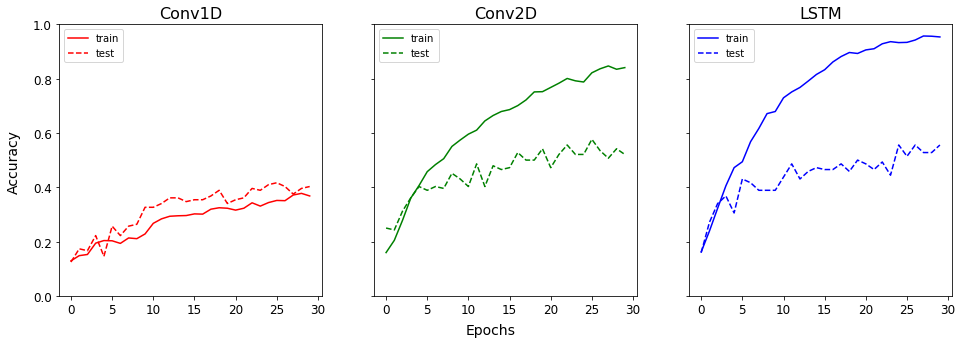

```python
fig, ax = plt.subplots(1, 3, sharey=True, figsize=(16,5))

for i, (fn, plt_label, c) in enumerate(zip(log_csvs, plt_labels, colors)):
    csv_path = os.path.join('logs', fn)
    dataf = pd.read_csv(csv_path)
    ax[i].set_title(plt_label, size=16)
    ax[i].plot(dataf.accuracy, color=c, label='train')
    ax[i].plot(dataf.val_accuracy, ls='--', color=c, label='test')
    ax[i].legend(loc='upper left')
    ax[i].tick_params(axis='both', which='major', labelsize=12)
    ax[i].set_ylim([0,1.0])

fig.text(0.5, 0.02, 'Epochs', ha='center', size=14)
fig.text(0.08, 0.5, 'Accuracy', va='center', rotation='vertical', size=14)
plt.show()
```

# Test Dataset Predictions

```python
MODEL_TYPE = 'LSTM'           # Conv1D, Conv2D or LSTM
MODEL_FN = f'models/{MODEL_TYPE}.h5'
```

```python
# Load model (with custom Kapre objects)
model = load_model(MODEL_FN, custom_objects={'Melspectrogram':Melspectrogram,
                                             'AdditiveNoise':AdditiveNoise,
                                             'Normalization2D':Normalization2D})
```

```
int_axis=-1 passed but is ignored, str_axis is used instead.
```

```python
# Shuffle must be false for the test batch, otherwise when it's called by model.predict() it will shuffle the order of indexes
# Thus making it so that the order in the array of indexes (test_batch.labels) does not match the order of the predicted probabilities
test_batch.shuffle = False
```

```python
model_eval = model.evaluate(test_batch)
```

```python
print(f'Test dataset loss:     {model_eval[0]}')
print(f'Test dataset accuracy: {model_eval[1]}')
```

```
Test dataset loss:     0.8481950759887695
Test dataset accuracy: 0.8472222089767456
```

Loss and accuracy as better on the prediction dataset because the noise layer (kapre AdditiveNoise) as well as the regularization elements (L2, Dropout) are not used during prediction. So essentialy the model was trained on a harder challenge than the one it's given during prediction.

```python
# label encoder sequence -> {'angry', 'calm', 'disgust', 'fearful', 'happy', 'neutral', 'sad', 'surprised'}
emotion_dict
```

```
{'01': 'neutral',
 '02': 'calm',
 '03': 'happy',
 '04': 'sad',
 '05': 'angry',
 '06': 'fearful',
 '07': 'disgust',
 '08': 'surprised'}
```

```python
# Check predicted probabilities
pred_probs = model.predict(test_batch)
pred_probs[0:2]
```

```
array([[0.02007039, 0.02494709, 0.0076588 , 0.02438794, 0.86311173,
        0.02487519, 0.02237405, 0.01257479],
       [0.00474171, 0.02582561, 0.01575668, 0.05045048, 0.01248823,
        0.02880808, 0.84782666, 0.01410257]], dtype=float32)
```

```python
# True encoding
true_encoding = test_batch.labels
true_encoding[0:10]
```

```
array([4, 6, 1, 2, 0, 7, 0, 2, 4, 2])
```

```python
# Sparse Categorical Cross Entropy
scce = tf.keras.losses.SparseCategoricalCrossentropy()
scce(true_encoding, pred_probs).numpy()
```

```
0.48790747
```

```python
# Predicted encoding
pred_encoding = np.argmax(pred_probs, axis=1)
pred_encoding[0:10]
```

```
array([4, 6, 1, 2, 0, 7, 0, 6, 4, 2], dtype=int64)
```

```python
# Manually calculate accuracy
sum((pred_encoding == true_encoding) / len(true_encoding))
```

```
0.8472222222222202
```

```python
# True labels
true_labels = le.inverse_transform(test_batch.labels)
true_labels[0:10]
```

```
array(['happy', 'sad', 'calm', 'disgust', 'angry', 'surprised', 'angry',
       'disgust', 'happy', 'disgust'], dtype='<U9')
```

```python
# Predicted labels
pred_labels = le.inverse_transform(pred_encoding)
pred_labels[0:10]
```

```
array(['happy', 'sad', 'calm', 'disgust', 'angry', 'surprised', 'angry',
       'sad', 'happy', 'disgust'], dtype='<U9')
```

```python
# Instance an one hot encoder object
onehot_encoder = OneHotEncoder(sparse=False)
```

```python
# {'angry', 'calm', 'disgust', 'fearful', 'happy', 'neutral', 'sad', 'surprised'}
true_onehot = onehot_encoder.fit_transform(true_encoding.reshape(-1, 1))
true_onehot[0:3]
```

```
array([[0., 0., 0., 0., 1., 0., 0., 0.],
       [0., 0., 0., 0., 0., 0., 1., 0.],
       [0., 1., 0., 0., 0., 0., 0., 0.]])
```

```python
# Predicted one_hot
pred_onehot = onehot_encoder.fit_transform(pred_encoding.reshape(-1, 1))
pred_onehot[0:3]
```

```
array([[0., 0., 0., 0., 1., 0., 0., 0.],
       [0., 0., 0., 0., 0., 0., 1., 0.],
       [0., 1., 0., 0., 0., 0., 0., 0.]])
```

```python
# Categorical Cross Entropy
cce = tf.keras.losses.CategoricalCrossentropy()
cce(true_onehot, pred_probs).numpy()
```

```
0.4879074
```

# Confusion Matrix and ROC

Scikit-Learn example: https://scikit-learn.org/stable/auto_examples/model_selection/plot_roc.html#sphx-glr-auto-examples-model-selection-plot-roc-py

```python
# Data for the plots
fpr = dict()
tpr = dict()
roc_auc = dict()
for i in range(N_CLASSES):
    fpr[i], tpr[i], _ = roc_curve(true_onehot[:, i], pred_probs[:, i])
    roc_auc[i] = auc(fpr[i], tpr[i])

# Compute micro-average ROC curve and ROC area
fpr["micro"], tpr["micro"], _ = roc_curve(true_onehot.ravel(), pred_probs.ravel())
roc_auc["micro"] = auc(fpr["micro"], tpr["micro"])
```

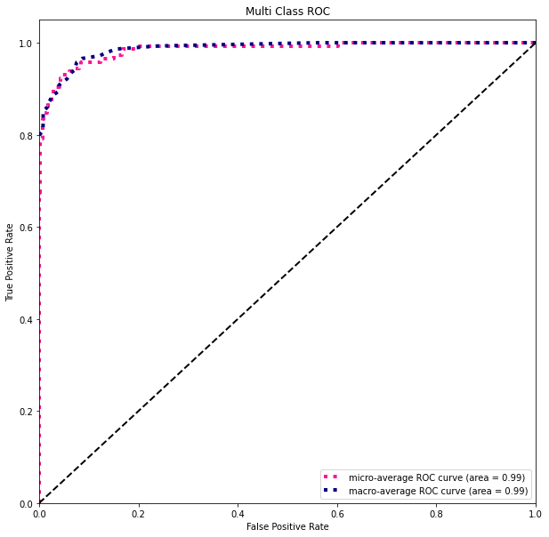

```python
# ROC-AUC Plot: Micro and Macro Scores

# First aggregate all false positive rates
all_fpr = np.unique(np.concatenate([fpr[i] for i in range(N_CLASSES)]))

# Then interpolate all ROC curves at this points
mean_tpr = np.zeros_like(all_fpr)
for i in range(N_CLASSES):
    mean_tpr += np.interp(all_fpr, fpr[i], tpr[i])

# Finally average it and compute AUC
mean_tpr /= N_CLASSES

fpr["macro"] = all_fpr
tpr["macro"] = mean_tpr
roc_auc["macro"] = auc(fpr["macro"], tpr["macro"])

# Plot all ROC curves
plt.figure(figsize=(10,10))
plt.plot(fpr["micro"], tpr["micro"],
         label='micro-average ROC curve (area = {0:0.2f})'
               ''.format(roc_auc["micro"]),
         color='deeppink', linestyle=':', linewidth=4)

plt.plot(fpr["macro"], tpr["macro"],
         label='macro-average ROC curve (area = {0:0.2f})'
               ''.format(roc_auc["macro"]),
         color='navy', linestyle=':', linewidth=4)


plt.plot([0, 1], [0, 1], 'k--', lw=2)
plt.xlim([0.0, 1.0])
plt.ylim([0.0, 1.05])
plt.xlabel('False Positive Rate')
plt.ylabel('True Positive Rate')
plt.title('Multi Class ROC')
legend = plt.legend()
legend._legend_box.align = "right"
plt.legend(loc="lower right")
plt.show()
```

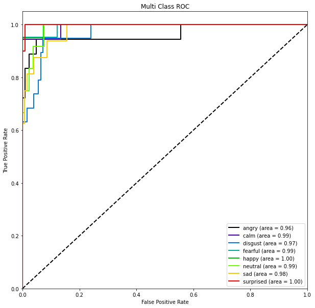

```python
# ROC-AUC Plot: Class Scores

plt.figure(figsize=(10,10))

colors = []
cm = pylab.get_cmap('nipy_spectral')
for i in range(N_CLASSES):
    color = cm(1.*i/N_CLASSES)
    colors.append(color)
unique_labels = np.unique(classes)

for i, color in zip(range(N_CLASSES), colors):
    plt.plot(fpr[i], tpr[i], color=color, lw=2,
             label='{0} (area = {1:0.2f})'.format(unique_labels[i], roc_auc[i]))

plt.plot([0, 1], [0, 1], 'k--', lw=2)
plt.xlim([0.0, 1.0])
plt.ylim([0.0, 1.05])
plt.xlabel('False Positive Rate')
plt.ylabel('True Positive Rate')
plt.title('Multi Class ROC')
legend = plt.legend()
legend._legend_box.align = "right"
plt.legend(loc="lower right")
plt.show()
```

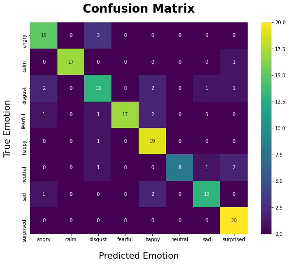

```python
conf_mat = confusion_matrix(true_labels, pred_labels, labels=unique_labels)
df_cm = pd.DataFrame(conf_mat, index = unique_labels,
                     columns = unique_labels)
plt.figure(figsize = (10,8))
plt.title('Confusion Matrix', fontsize = 24, pad = 20, fontweight='bold')
sns.heatmap(df_cm, annot=True, cmap='viridis')
plt.ylabel('True Emotion', fontsize = 18, labelpad = 20)
plt.xlabel('Predicted Emotion', fontsize = 18, labelpad = 20)
plt.show()
```

```python
# Metrics
precision = precision_score(true_encoding, pred_encoding, average = 'macro')
recall = recall_score(true_encoding, pred_encoding, average = 'macro')
f1_sc = f1_score(true_encoding, pred_encoding, average = 'macro')
accuracy_sc = accuracy_score(true_encoding, pred_encoding)
roc_auc_macro = roc_auc['macro']
```

```python
print('Model Performance Metrics:')
print(f'Precision  =  {precision:.5f}')
print(f'Recal      =  {recall:.5f}')
print(f'F1 Score   =  {f1_sc:.5f}')
print(f'Accuracy   =  {accuracy_sc:.5f}')
print(f'ROC-AUC    =  {roc_auc_macro:.5f}')
```

```
Model Performance Metrics:
Precision  =  0.86671
Recal      =  0.83758
F1 Score   =  0.84418
Accuracy   =  0.84722
ROC-AUC    =  0.98774
```